# Rapport statistique DPE 69

Christophe DEPIN, Arthur MALLIERE, Oleksandr Lisovyi

2025-11-16

# 1. Objet du rapport

Ce rapport présente une analyse descriptive des Diagnostics de Performance Énergétique (DPE) du département du Rhône (69) à partir de l’API ADEME, en cohérence avec l’application **projet_r_shiny**.

Les paramètres utilisés sont définis en en-tête :

- `params$code_postal` :
  - `"69"` pour l’ensemble des DPE du département,
  - ou un code postal ciblé.
- `params$type_logement` :
  - `"Existant"`, `"Neuf"` ou `"les deux"`.

# 2. Importation et préparation des données

```r
# Lecture des adresses pour déterminer les codes postaux du 69
adresses_69 <- read.csv(
  "adresses-69.csv",
  header = TRUE, sep = ";", dec = ".", encoding = "latin1"
)

if (params$code_postal == "69") {
  code_postaux <- sort(unique(adresses_69$code_postal))
} else {
  code_postaux <- params$code_postal
}

# Récupération des DPE existants et neufs
dpe_ex <- fetch_dpe_existant(code_postaux)
dpe_ne <- fetch_dpe_neuf(code_postaux)

if (is.null(dpe_ex)) dpe_ex <- data.frame()
if (is.null(dpe_ne)) dpe_ne <- data.frame()

dpe_all <- plyr::rbind.fill(dpe_ex, dpe_ne)

# Filtre sur le type de logement
if (params$type_logement != "les deux") {
  dpe_all <- dpe_all %>% dplyr::filter(type_logement == params$type_logement)
}

nb_dpe <- nrow(dpe_all)

# Normalisation des étiquettes DPE
if ("etiquette_dpe" %in% names(dpe_all)) {
  dpe_all$etiquette_clean <- toupper(trimws(dpe_all$etiquette_dpe))
  dpe_all$etiquette_clean[!(dpe_all$etiquette_clean %in% valid_letters)] <- NA
} else {
  dpe_all$etiquette_clean <- NA
}

# Gestion des outliers sur la surface (p1–p99)
if ("surface_habitable_logement" %in% names(dpe_all)) {
  res_trim <- trim_var_for_plot(dpe_all, "surface_habitable_logement")
  dpe_all  <- res_trim$df
}

nb_dpe <- nrow(dpe_all)

glimpse(dpe_all)
```

```
## Rows: 21,918
## Columns: 56
## $ numero_voie_ban                   <chr> "2", "21", "39", "12", NA, "4", "9",…
## $ score_ban                         <dbl> 0.61, 0.62, 0.65, 0.59, 0.68, 0.59, …
## $ emission_ges_5_usages_par_m2      <dbl> 55.0, 9.0, 13.0, 44.0, 7.8, 6.0, 58.…
## $ cout_eclairage                    <dbl> 55.3, 12.4, 10.7, 26.1, 32.1, 11.5, …
## $ besoin_chauffage                  <dbl> 15865.7, 3240.7, 4975.7, 5260.4, 381…
## $ classe_inertie_batiment           <chr> "Légère", "Légère", "Lourde", "Moyen…
## $ cout_chauffage                    <dbl> 1634.5, 560.3, 830.1, 676.5, 611.0, …
## $ conso_5_usages_par_m2_ep          <dbl> 251.0, 305.0, 414.0, 221.0, 242.1, 2…
## $ date_etablissement_dpe            <date> 2022-04-13, 2022-06-21, 2022-01-19,…
## $ conso_5_usages_par_m2_ef          <dbl> 246.0, 133.0, 180.0, 205.0, 105.3, 9…
## $ nom_commune_ban                   <chr> "Lyon", "Lyon", "Lyon", "Lyon", "Lyo…
## $ annee_construction                <dbl> 1947, NA, 1947, NA, 1950, NA, 1900, …
## $ `_geopoint`                       <chr> "45.76930597016141,4.826277025671088…
```

[output cut: 43 more lines]

# 3. Indicateurs principaux (KPI)

```r
if (nb_dpe == 0) {
  cat("Aucun DPE disponible pour ces paramètres (code postal / type de logement).")
} else {
  surf_moy  <- mean(dpe_all$surface_habitable_logement, na.rm = TRUE)
  surf_med  <- median(dpe_all$surface_habitable_logement, na.rm = TRUE)

  if ("annee_construction" %in% names(dpe_all)) {
    annee_med <- median(dpe_all$annee_construction, na.rm = TRUE)
  } else {
    annee_med <- NA
  }

  part_ABC <- mean(dpe_all$etiquette_clean %in% c("A","B","C"), na.rm = TRUE) * 100

  date_cols_presentes <- intersect(
    c("date_etablissement_dpe","date_reception_dpe"),
    names(dpe_all)
  )
  if (length(date_cols_presentes) > 0) {
    dates_cand <- do.call(
      c,
      lapply(date_cols_presentes, function(col) dpe_all[[col]])
    )
    last_date <- suppressWarnings(max(dates_cand, na.rm = TRUE))
    if (!is.finite(last_date)) last_date <- NA
  } else {
    last_date <- NA
  }

  cat("
## KPI

- Nombre total de DPE : ", nb_dpe, "
- Surface moyenne : ", round(surf_moy,1), " m²
- Surface médiane : ", round(surf_med,1), " m²
- Année médiane de construction (si disponible) : ", annee_med, "
- Part des logements en classes A–B–C : ", round(part_ABC,1), " %
- Dernière date disponible (réception ou établissement) : ",
      ifelse(is.na(last_date), "Non disponible", format(last_date, "%d/%m/%Y")), "
")
}
```

```
##
## ## KPI
##
## - Nombre total de DPE :  21918
## - Surface moyenne :  84.9  m²
## - Surface médiane :  73.4  m²
## - Année médiane de construction (si disponible) :  1970
## - Part des logements en classes A–B–C :  30.5  %
## - Dernière date disponible (réception ou établissement) :  08/11/2025
```

# 4. Contexte et répartition des DPE

## 4.1 Répartition des étiquettes DPE

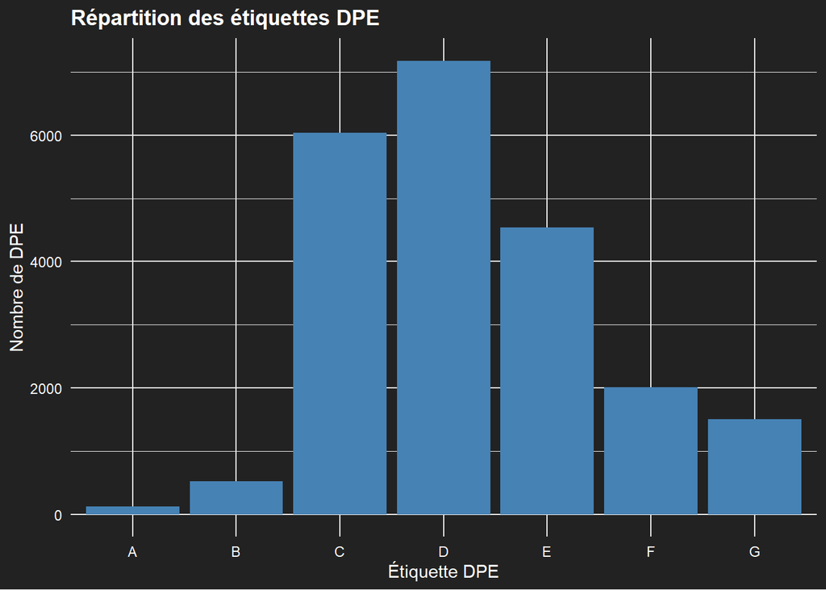

```r
if (nb_dpe > 0 && "etiquette_dpe" %in% names(dpe_all)) {
  ggplot(dpe_all, aes(x = etiquette_dpe)) +
    geom_bar(fill = "steelblue") +
    theme_app_dark() +
    labs(
      title = "Répartition des étiquettes DPE",
      x = "Étiquette DPE",
      y = "Nombre de DPE"
    )
} else {
  cat("Répartition des étiquettes non disponible.")
}
```

## 4.2 Histogramme des surfaces (p1–p99)

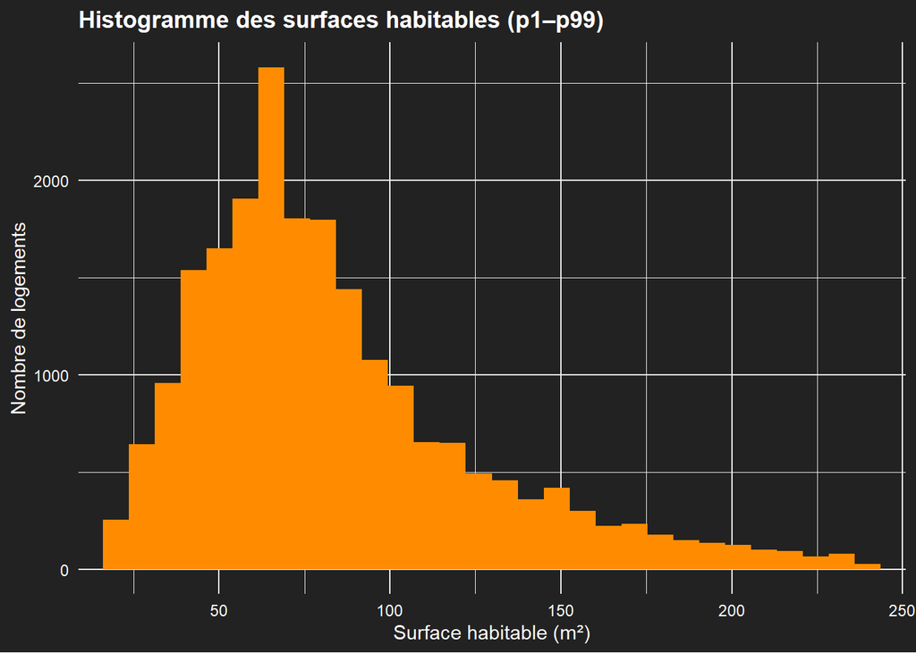

```r
if (nb_dpe > 0 && "surface_habitable_logement" %in% names(dpe_all)) {
  res <- trim_var_for_plot(dpe_all, "surface_habitable_logement")

  ggplot(res$df, aes(surface_habitable_logement)) +
    geom_histogram(bins = 30, fill = "darkorange") +
    theme_app_dark() +
    coord_cartesian(xlim = res$limits) +
    labs(
      title = "Histogramme des surfaces habitables (p1–p99)",
      x = "Surface habitable (m²)",
      y = "Nombre de logements"
    )
} else {
  cat("Histogramme des surfaces non disponible.")
}
```

# 5. Analyse univariée

## 5.1 Distribution d’une variable énergétique

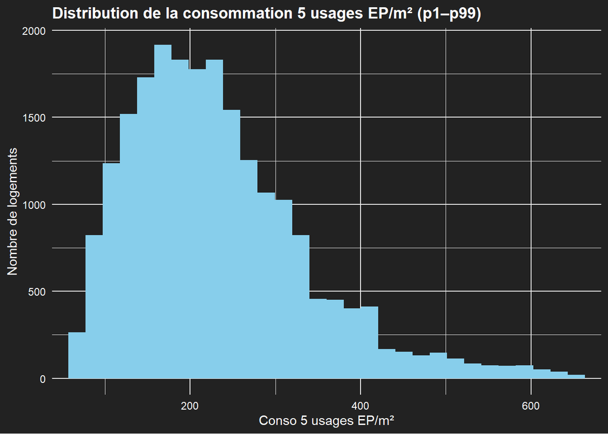

```r
if (nb_dpe > 0 && "conso_5_usages_par_m2_ep" %in% names(dpe_all)) {
  res <- trim_var_for_plot(dpe_all, "conso_5_usages_par_m2_ep")

  ggplot(res$df, aes(conso_5_usages_par_m2_ep)) +
    geom_histogram(bins = 30, fill = "skyblue") +
    theme_app_dark() +
    coord_cartesian(xlim = res$limits) +
    labs(
      title = "Distribution de la consommation 5 usages EP/m² (p1–p99)",
      x = "Conso 5 usages EP/m²",
      y = "Nombre de logements"
    )
} else {
  cat("Variable conso_5_usages_par_m2_ep non disponible.")
}
```

## 5.2 Boîte à moustaches par type de logement

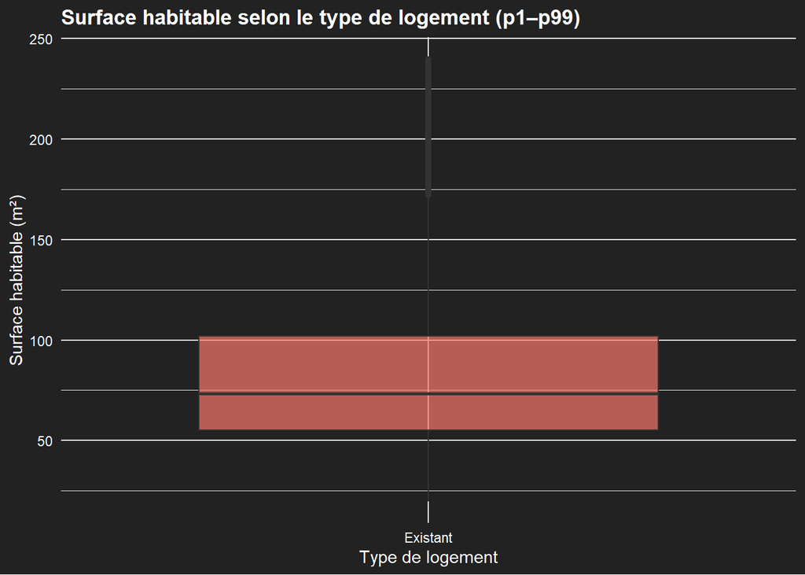

```r
if (nb_dpe > 0 &&
    "type_logement" %in% names(dpe_all) &&
    "surface_habitable_logement" %in% names(dpe_all)) {

  res <- trim_var_for_plot(dpe_all, "surface_habitable_logement")

  ggplot(res$df,
         aes(type_logement,
             surface_habitable_logement,
             fill = type_logement)) +
    geom_boxplot(alpha = 0.7) +
    theme_app_dark() +
    theme(legend.position = "none") +
    labs(
      title = "Surface habitable selon le type de logement (p1–p99)",
      x = "Type de logement",
      y = "Surface habitable (m²)"
    )
} else {
  cat("Boîte à moustaches non disponible (variables manquantes).")
}
```

# 6. Analyse bivariée : surface et coût

Cette partie met en relation la surface habitable et le coût total des cinq usages, avec un nuage de points, une droite de régression linéaire et des indicateurs bivariés.

## 6.1 Nuage de points surface / coût total

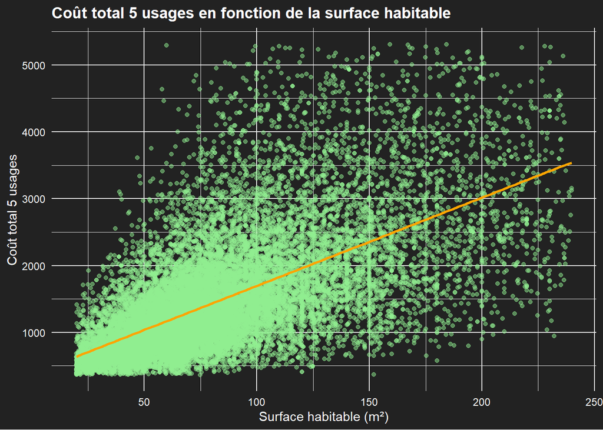

```r
if (nb_dpe > 0 &&
    "surface_habitable_logement" %in% names(dpe_all) &&
    "cout_total_5_usages" %in% names(dpe_all)) {

  df_biv <- dpe_all %>%
    dplyr::filter(
      !is.na(surface_habitable_logement),
      !is.na(cout_total_5_usages)
    )

  res_surf <- trim_var_for_plot(df_biv, "surface_habitable_logement")
  df_biv   <- res_surf$df
  res_cout <- trim_var_for_plot(df_biv, "cout_total_5_usages")
  df_biv   <- res_cout$df

  if (nrow(df_biv) > 10) {
    ggplot(df_biv,
           aes(surface_habitable_logement,
               cout_total_5_usages)) +
      geom_point(alpha = 0.5, color = "lightgreen") +
      geom_smooth(method = "lm", se = FALSE, color = "orange") +
      theme_app_dark() +
      labs(
        title = "Coût total 5 usages en fonction de la surface habitable",
        x = "Surface habitable (m²)",
        y = "Coût total 5 usages"
      )
  } else {
    cat("Nuage de points non tracé (données insuffisantes).")
  }

} else {
  cat("Variables nécessaires non disponibles pour l'analyse bivariée.")
}
```

## 6.2 Corrélation et régression linéaire surface / coût

```r
if (nb_dpe > 0 &&
    "surface_habitable_logement" %in% names(dpe_all) &&
    "cout_total_5_usages" %in% names(dpe_all)) {

  df_biv <- dpe_all %>%
    dplyr::filter(
      !is.na(surface_habitable_logement),
      !is.na(cout_total_5_usages)
    )

  if (nrow(df_biv) > 10) {
    vx <- as.numeric(df_biv$surface_habitable_logement)
    vy <- as.numeric(df_biv$cout_total_5_usages)

    if (sd(vx, na.rm = TRUE) > 0 && sd(vy, na.rm = TRUE) > 0) {
      corr <- cor(vx, vy, use = "complete.obs")
      cat("Coefficient de corrélation (Pearson) surface / coût :", round(corr, 3), "\n\n")
      print(summary(lm(vy ~ vx)))
    } else {
      cat("Dispersion insuffisante pour calculer une corrélation pertinente.")
    }
  } else {
    cat("Données insuffisantes pour estimer une régression linéaire fiable.")
  }

} else {
  cat("Variables nécessaires non disponibles pour les statistiques bivariées.")
}
```

```
## Coefficient de corrélation (Pearson) surface / coût : 0.651
##
##
## Call:
## lm(formula = vy ~ vx)
##
## Residuals:
##     Min      1Q  Median      3Q     Max
## -3230.1  -422.3  -109.5   247.2  9198.5
##
## Coefficients:
##             Estimate Std. Error t value Pr(>|t|)
## (Intercept) 265.1999    11.3150   23.44   <2e-16 ***
## vx           14.8633     0.1176  126.40   <2e-16 ***
## ---
## Signif. codes:  0 '***' 0.001 '**' 0.01 '*' 0.05 '.' 0.1 ' ' 1
##
## Residual standard error: 784.9 on 21714 degrees of freedom
## Multiple R-squared:  0.4239, Adjusted R-squared:  0.4239
## F-statistic: 1.598e+04 on 1 and 21714 DF,  p-value: < 2.2e-16
```

# 7. Énergie et coûts

## 7.1 Coût total 5 usages par étiquette DPE

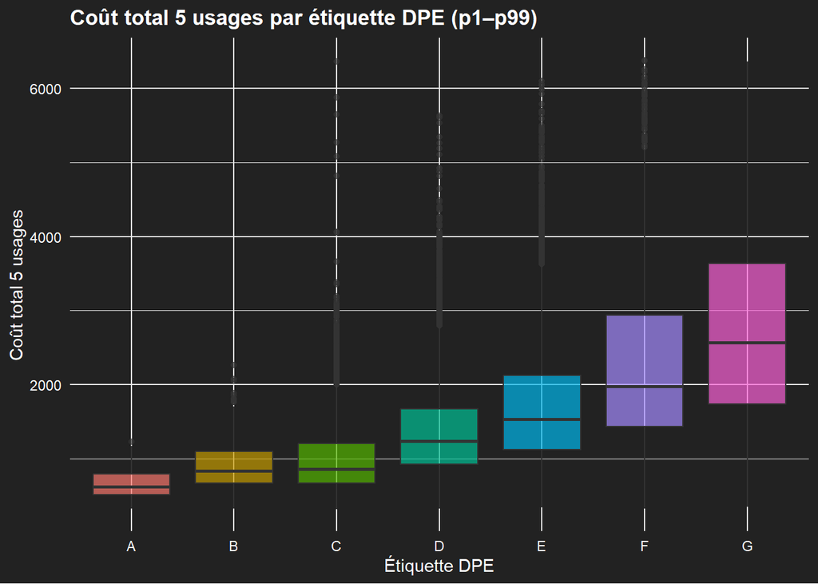

```r
if (nb_dpe > 0 &&
    "cout_total_5_usages" %in% names(dpe_all) &&
    "etiquette_dpe" %in% names(dpe_all)) {

  df_cout <- dpe_all %>%
    dplyr::filter(
      !is.na(cout_total_5_usages),
      !is.na(etiquette_dpe)
    )

  if (nrow(df_cout) > 0) {
    res <- trim_var_for_plot(df_cout, "cout_total_5_usages")

    ggplot(res$df,
           aes(etiquette_dpe,
               cout_total_5_usages,
               fill = etiquette_dpe)) +
      geom_boxplot(alpha = 0.7) +
      theme_app_dark() +
      theme(legend.position = "none") +
      labs(
        title = "Coût total 5 usages par étiquette DPE (p1–p99)",
        x = "Étiquette DPE",
        y = "Coût total 5 usages"
      )
  } else {
    cat("Données de coût insuffisantes pour tracer la boîte à moustaches.")
  }

} else {
  cat("Variables cout_total_5_usages / etiquette_dpe non disponibles.")
}
```

## 7.2 Répartition des énergies de chauffage

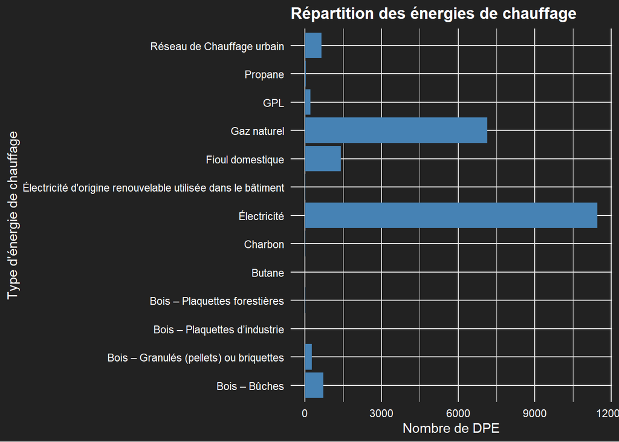

```r
if (nb_dpe > 0 &&
    "type_energie_principale_chauffage" %in% names(dpe_all)) {

  df_ch <- dpe_all %>%
    dplyr::filter(!is.na(type_energie_principale_chauffage))

  if (nrow(df_ch) > 0) {
    ggplot(df_ch,
           aes(x = type_energie_principale_chauffage)) +
      geom_bar(fill = "steelblue") +
      theme_app_dark() +
      coord_flip() +
      labs(
        title = "Répartition des énergies de chauffage",
        x = "Type d'énergie de chauffage",
        y = "Nombre de DPE"
      )
  } else {
    cat("Aucune information exploitable sur le type d'énergie de chauffage.")
  }

} else {
  cat("Variable type_energie_principale_chauffage non disponible.")
}
```

## 7.3 Histogramme de la consommation 5 usages EP/m²

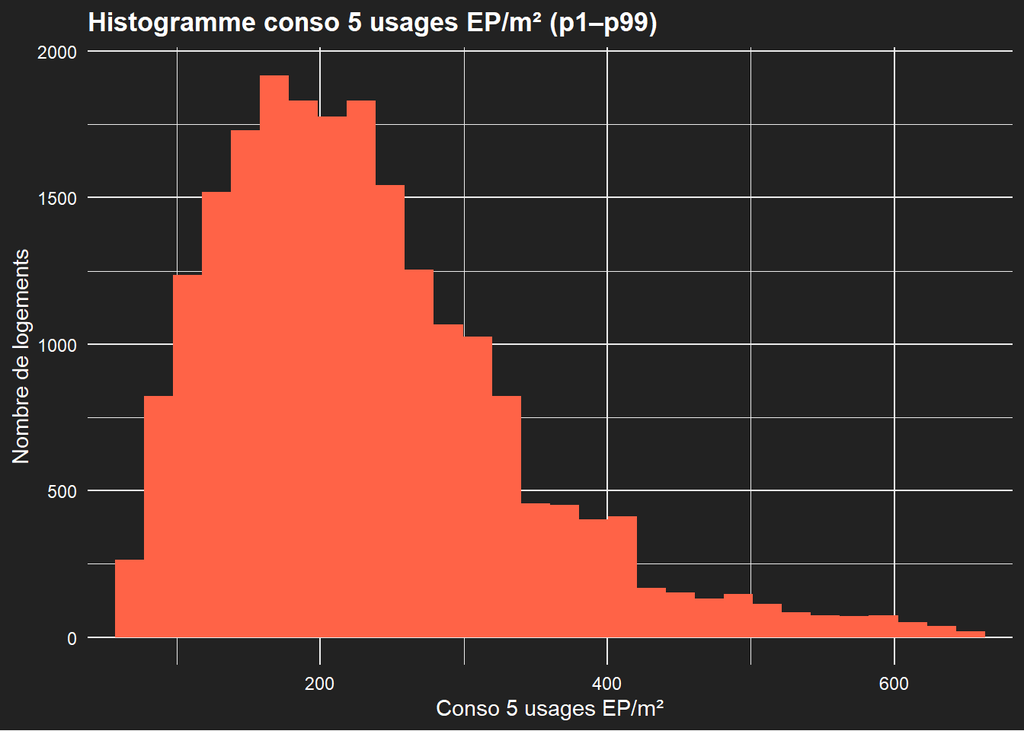

```r
if (nb_dpe > 0 &&
    "conso_5_usages_par_m2_ep" %in% names(dpe_all)) {

  res <- trim_var_for_plot(dpe_all, "conso_5_usages_par_m2_ep")

  ggplot(res$df,
         aes(conso_5_usages_par_m2_ep)) +
    geom_histogram(bins = 30, fill = "tomato") +
    theme_app_dark() +
    coord_cartesian(xlim = res$limits) +
    labs(
      title = "Histogramme conso 5 usages EP/m² (p1–p99)",
      x = "Conso 5 usages EP/m²",
      y = "Nombre de logements"
    )
} else {
  cat("Histogramme conso EP/m² non disponible.")
}
```

## 7.4 Répartition des énergies ECS

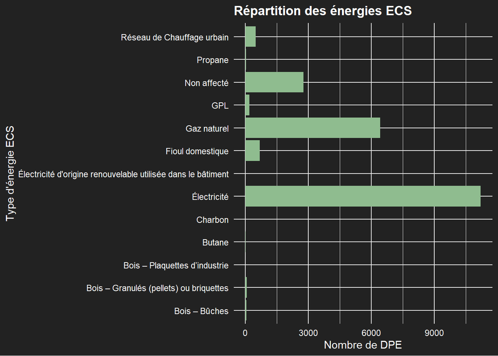

```r
if (nb_dpe > 0 &&
    "type_energie_principale_ecs" %in% names(dpe_all)) {

  df_ecs <- dpe_all %>%
    dplyr::filter(!is.na(type_energie_principale_ecs))

  if (nrow(df_ecs) > 0) {
    ggplot(df_ecs,
           aes(x = type_energie_principale_ecs)) +
      geom_bar(fill = "darkseagreen") +
      theme_app_dark() +
      coord_flip() +
      labs(
        title = "Répartition des énergies ECS",
        x = "Type d'énergie ECS",
        y = "Nombre de DPE"
      )
  } else {
    cat("Aucune information exploitable sur le type d'énergie ECS.")
  }

} else {
  cat("Variable type_energie_principale_ecs non disponible.")
}
```

# 8. Conclusion

Ce rapport RMarkdown est aligné sur l’application **projet_r_shiny** :

- exploitation de l’API ADEME sur tout le département 69 ou sur un code postal ciblé ;
- calcul d’indicateurs synthétiques (KPI) sur les volumes, surfaces, années de construction, classes DPE et dates de mise à disposition ;
- représentation graphique cohérente avec l’interface Shiny :  
  histogrammes, boîtes à moustaches, nuage de points avec droite de régression surface / coût total, distributions des énergies de chauffage et d’ECS, coûts par étiquette DPE ;
- filtrage des valeurs extrêmes par un encadrement p1–p99, afin de stabiliser les visualisations et les indicateurs.